# LB-TritonX GR analysis

Kenyon

December 22, 2015

#### Grew 7 strains on LB+0.008% Triton X for 16hrs in plate reader, generating 7 replicates

Import files:

```r
source('~/Bacillus_subtilis/Growth Rates/growth-curves-ryan/GrowthRateScripts_Dec2015/1_import_csvs.R')

folder_name<-"C:/Users/Kenyon/Documents/Bacillus_subtilis/Growth Rates/Eon data/LB+Triton-X/"
file_names<-list.files(folder_name,pattern="*tritonx...csv")
obj_name<-"tritX"

file_names
```

```
## [1] "2015-12-09-lb-tritonx-1.csv" "2015-12-16-lb-tritonx-2.csv"
## [3] "2015-12-17-lb-tritonx-3.csv" "2015-12-18-lb-tritonx-4.csv"
## [5] "2015-12-19-lb-tritonx-5.csv" "2015-12-20-lb-tritonx-6.csv"
## [7] "2015-12-21-lb-tritonx-7.csv"
```

Merge individual ‘.csv’ files into one:

```r
for (i in 1:length(file_names)){
  x<-read.csv(paste0(folder_name,file_names[i]),header = FALSE)
  assign(paste0(obj_name,i),x)
}

tritX<-rbind(tritX1,tritX2[-1,],tritX3[-1,],tritX4[-1,],tritX5[-1,],tritX6[-1,],tritX7[-1,])

tritX[,2]<-c("media",rep("LB+Trit",times=nrow(tritX)-1))

write.csv(tritX,"C:/Users/Kenyon/Documents/Bacillus_subtilis/Growth Rates/Eon data/LB+Triton-X/CMN-TritonXLB-2015-12-21.csv")
```

- open grofit function, no overlay of plots so bad plots can be identified
- in ln set, get 2 curves that are mis-identified at hr0; remove columns 5:15 (0.16-1.83hrs)

```r
source('~/Bacillus_subtilis/Growth Rates/growth-curves-ryan/no_overlay-gc_combined/grofit-combined-no_overlay.R')

tridat<-gcfall_no(tritX)   #already run, do not need to do again
```

- all data to date processed fine, except that some curves have much flatter peaks while others are pointy

#### observations:

- MN and AM373 generally had flat peaks, others were pointy
- the max point in flat peaks was usually identified at later timepoints in flat region
- appears as though CssS-containing strains lyse much faster than other strains

#### data to remove:

```r
tritX<-tritX[,-5:-15]
tritX<-tritX[-which(tritX[,1]=="Dec-16"& tritX[,4]=="D3"),]
```

using version of ‘gcfall’ that merges ln=TRUE and ln=FALSE datasets

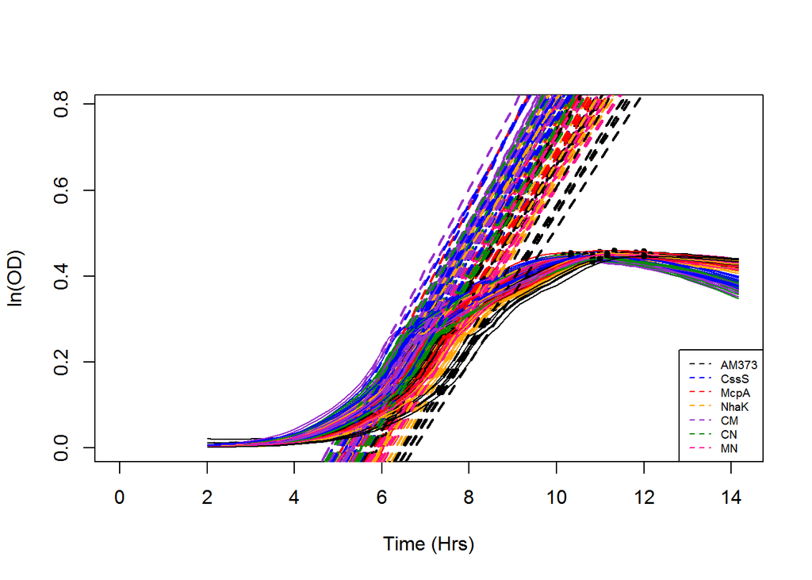

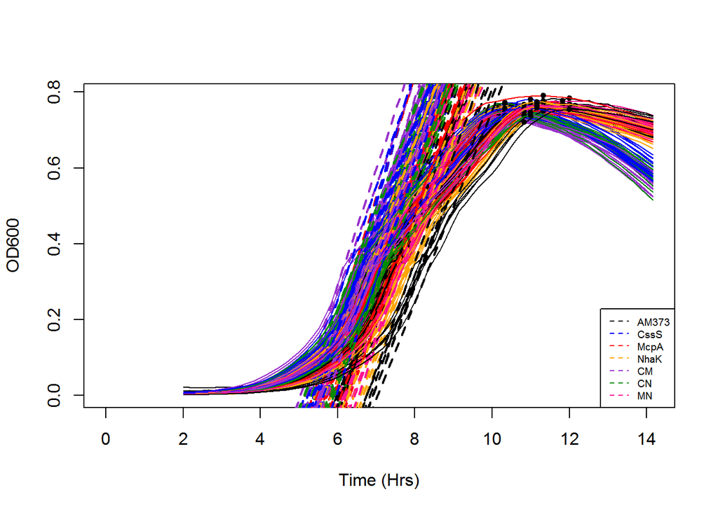

```r
source('~/Bacillus_subtilis/Growth Rates/growth-curves-ryan/GrowthRateScripts_Dec2015/3_gcfall-media-lnmerge.R')

tridat2<-gcfall_mergeln(tritX)
```

**observations:**

- non-CssS strains appear to decline into lysis less quicky (but not assayed as far into that region of growth)
- the max point in flat peaks was usually identified at later timepoints in flat region
- CssS strains appeared to enter exponential phase sooner, AM373 last (less/more lag)

#### save data and combine technical replicates:

```r
write.csv(tridat2,"C:/Users/Kenyon/Documents/Bacillus_subtilis/Growth Rates/Eon data/LB+Triton-X/CMN-TritonXLB-gcfit-2015-12-22.csv")

# Combine technical replicates
source('~/Bacillus_subtilis/Growth Rates/growth-curves-ryan/LM_controls-Sept2015/average_triples_ingcobj.R')

trit<-avg_triples(tridat2,"DEF")

write.csv(trit,"C:/Users/Kenyon/Documents/Bacillus_subtilis/Growth Rates/Eon data/LB+Triton-X/CMN-TritonXLB-gcfit-repsavgd-2015-12-21.csv")
```

### plot of GR paramaters

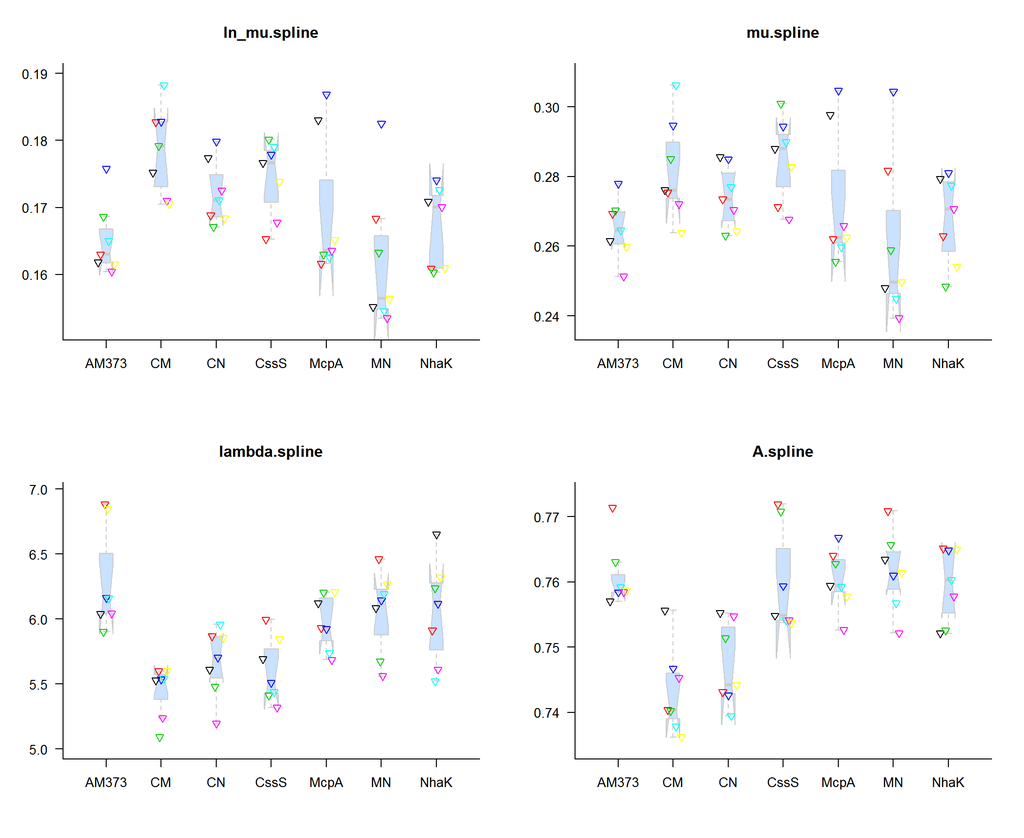

```r
source('~/Bacillus_subtilis/Growth Rates/growth-curves-ryan/LM_controls-Sept2015/gcf-tplot-by-strain.R')
errort.bars(trit)
```

**ln_mu.spline:**

[output not shown]

**lambda.spline:**

[output not shown]

```r
source('~/Bacillus_subtilis/Growth Rates/growth-curves-ryan/LM_controls-Sept2015/gcftukeyrun_rM.R')

tri_tuk<-tukeyrun(trit,c(11,13:15))

tri_tuk[,3:5]<-signif(tri_tuk[,3:5],digits = 3)

print(tri_tuk[which(tri_tuk$pvals<0.05),])
```

```
##                        meas    strains    difs perc_dif    pvals p05
## CM-AM373       ln_mu.spline   CM-AM373  0.0133   0.0808 3.19e-03   *
## MN-CM          ln_mu.spline      MN-CM -0.0166  -0.1000 1.65e-04   *
## NhaK-CM        ln_mu.spline    NhaK-CM -0.0114  -0.0691 1.65e-02   *
## MN-CN          ln_mu.spline      MN-CN -0.0102  -0.0618 4.24e-02   *
## MN-CssS        ln_mu.spline    MN-CssS -0.0124  -0.0752 7.09e-03   *
## CM-AM3731     lambda.spline   CM-AM373 -0.8430  -0.1340 1.07e-06   *
## CN-AM3731     lambda.spline   CN-AM373 -0.6240  -0.0991 2.36e-04   *
## CssS-AM3731   lambda.spline CssS-AM373 -0.6890  -0.1260 4.74e-05   *
## McpA-CM1      lambda.spline    McpA-CM  0.5250   0.0964 2.45e-03   *
## MN-CM1        lambda.spline      MN-CM  0.6070   0.0964 3.54e-04   *
## NhaK-CM1      lambda.spline    NhaK-CM  0.6050   0.0962 3.67e-04   *
## MN-CN1        lambda.spline      MN-CN  0.3870   0.0616 4.75e-02   *
## NhaK-CN1      lambda.spline    NhaK-CN  0.3860   0.0708 4.88e-02   *
## MN-CssS1      lambda.spline    MN-CssS  0.4530   0.0720 1.24e-02   *
## NhaK-CssS1    lambda.spline  NhaK-CssS  0.4510   0.0829 1.28e-02   *
## CM-AM3732          A.spline   CM-AM373 -0.0177  -0.0233 3.57e-05   *
## CN-AM3732          A.spline   CN-AM373 -0.0136  -0.0179 1.76e-03   *
## CssS-CM2           A.spline    CssS-CM  0.0167   0.0219 9.86e-05   *
## McpA-CM2           A.spline    McpA-CM  0.0172   0.0232 5.81e-05   *
## MN-CM2             A.spline      MN-CM  0.0184   0.0242 1.74e-05   *
## NhaK-CM2           A.spline    NhaK-CM  0.0165   0.0217 1.15e-04   *
## CssS-CN2           A.spline    CssS-CN  0.0126   0.0169 4.55e-03   *
## McpA-CN2           A.spline    McpA-CN  0.0131   0.0173 2.78e-03   *
## MN-CN2             A.spline      MN-CN  0.0144   0.0189 8.83e-04   *
## NhaK-CN2           A.spline    NhaK-CN  0.0124   0.0167 5.25e-03   *
## CssS-AM3733 integral.spline CssS-AM373  0.3590   0.0722 1.41e-02   *
```

```r
print(tri_tuk)
```

```
##                        meas    strains      difs  perc_dif    pvals p05
## CM-AM373       ln_mu.spline   CM-AM373  0.013300  0.080800 3.19e-03   *
## CN-AM373       ln_mu.spline   CN-AM373  0.006980  0.042300 3.30e-01
## CssS-AM373     ln_mu.spline CssS-AM373  0.009190  0.051500 8.82e-02
## McpA-AM373     ln_mu.spline McpA-AM373  0.004220  0.025600 8.38e-01
## MN-AM373       ln_mu.spline   MN-AM373 -0.003230 -0.019500 9.49e-01
## NhaK-AM373     ln_mu.spline NhaK-AM373  0.001930  0.010800 9.96e-01
## CN-CM          ln_mu.spline      CN-CM -0.006360 -0.038500 4.40e-01
## CssS-CM        ln_mu.spline    CssS-CM -0.004150 -0.025100 8.49e-01
## McpA-CM        ln_mu.spline    McpA-CM -0.009120 -0.051100 9.29e-02
## MN-CM          ln_mu.spline      MN-CM -0.016600 -0.100000 1.65e-04   *
## NhaK-CM        ln_mu.spline    NhaK-CM -0.011400 -0.069100 1.65e-02   *
## CssS-CN        ln_mu.spline    CssS-CN  0.002210  0.012400 9.92e-01
## McpA-CN        ln_mu.spline    McpA-CN -0.002760 -0.016700 9.76e-01
## MN-CN          ln_mu.spline      MN-CN -0.010200 -0.061800 4.24e-02   *
## NhaK-CN        ln_mu.spline    NhaK-CN -0.005050 -0.028300 6.97e-01
## McpA-CssS      ln_mu.spline  McpA-CssS -0.004970 -0.030100 7.12e-01
## MN-CssS        ln_mu.spline    MN-CssS -0.012400 -0.075200 7.09e-03   *
## NhaK-CssS      ln_mu.spline  NhaK-CssS -0.007260 -0.040700 2.86e-01
## MN-McpA        ln_mu.spline    MN-McpA -0.007450 -0.045100 2.59e-01
## NhaK-McpA      ln_mu.spline  NhaK-McpA -0.002290 -0.013900 9.91e-01
## NhaK-MN        ln_mu.spline    NhaK-MN  0.005160  0.028900 6.76e-01
## CM-AM3731     lambda.spline   CM-AM373 -0.843000 -0.134000 1.07e-06   *
## CN-AM3731     lambda.spline   CN-AM373 -0.624000 -0.099100 2.36e-04   *
## CssS-AM3731   lambda.spline CssS-AM373 -0.689000 -0.126000 4.74e-05   *
## McpA-AM3731   lambda.spline McpA-AM373 -0.318000 -0.050500 1.63e-01
## MN-AM3731     lambda.spline   MN-AM373 -0.236000 -0.037500 4.83e-01
## NhaK-AM3731   lambda.spline NhaK-AM373 -0.238000 -0.043600 4.76e-01
## CN-CM1        lambda.spline      CN-CM  0.219000  0.034900 5.70e-01
## CssS-CM1      lambda.spline    CssS-CM  0.154000  0.024500 8.70e-01
## McpA-CM1      lambda.spline    McpA-CM  0.525000  0.096400 2.45e-03   *
## MN-CM1        lambda.spline      MN-CM  0.607000  0.096400 3.54e-04   *
## NhaK-CM1      lambda.spline    NhaK-CM  0.605000  0.096200 3.67e-04   *
## CssS-CN1      lambda.spline    CssS-CN -0.065500 -0.012000 9.98e-01
## McpA-CN1      lambda.spline    McpA-CN  0.306000  0.048600 1.96e-01
## MN-CN1        lambda.spline      MN-CN  0.387000  0.061600 4.75e-02   *
## NhaK-CN1      lambda.spline    NhaK-CN  0.386000  0.070800 4.88e-02   *
## McpA-CssS1    lambda.spline  McpA-CssS  0.371000  0.059000 6.44e-02
## MN-CssS1      lambda.spline    MN-CssS  0.453000  0.072000 1.24e-02   *
## NhaK-CssS1    lambda.spline  NhaK-CssS  0.451000  0.082900 1.28e-02   *
```

[output cut: 30 more lines]

```
## CN-CM3      integral.spline      CN-CM -0.113000 -0.023900 9.10e-01
## CssS-CM3    integral.spline    CssS-CM  0.123000  0.026100 8.71e-01
## McpA-CM3    integral.spline    McpA-CM -0.004340 -0.000875 1.00e+00
## MN-CM3      integral.spline      MN-CM -0.041000 -0.008670 1.00e+00
## NhaK-CM3    integral.spline    NhaK-CM -0.091400 -0.019300 9.66e-01
## CssS-CN3    integral.spline    CssS-CN  0.236000  0.047600 2.32e-01
## McpA-CN3    integral.spline    McpA-CN  0.109000  0.023000 9.24e-01
## MN-CN3      integral.spline      MN-CN  0.072100  0.015200 9.90e-01
## NhaK-CN3    integral.spline    NhaK-CN  0.021700  0.004370 1.00e+00
## McpA-CssS3  integral.spline  McpA-CssS -0.128000 -0.027000 8.51e-01
## MN-CssS3    integral.spline    MN-CssS -0.164000 -0.034800 6.45e-01
## NhaK-CssS3  integral.spline  NhaK-CssS -0.215000 -0.043300 3.36e-01
## MN-McpA3    integral.spline    MN-McpA -0.036700 -0.007750 1.00e+00
## NhaK-McpA3  integral.spline  NhaK-McpA -0.087000 -0.018400 9.73e-01
## NhaK-MN3    integral.spline    NhaK-MN -0.050400 -0.010100 9.99e-01
```